# NAME: YOUR_NAME

### Step 1: Load Image and Compute Energy Map

- We first load the image `prague.png` located inside this folder.
- Then, we compute the energy map which is a 2D array of values of "interestingness" (dark regions: low interestingness, bright regions: high interestingness)

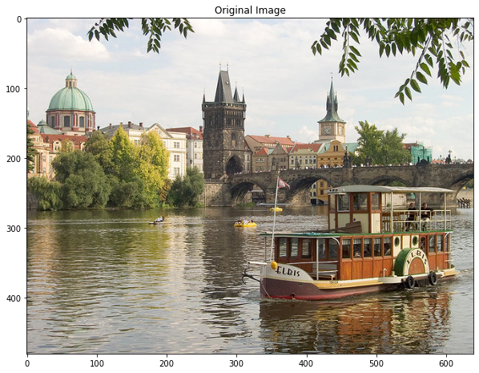

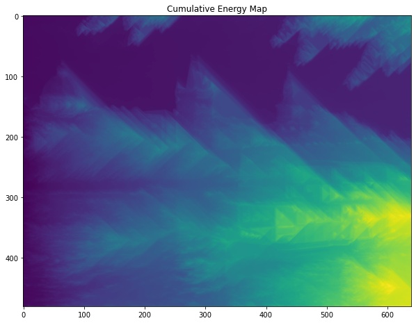

```python
import matplotlib.image as mpimg
import matplotlib.pyplot as plt
from vision_utils import cumulativeMinimumEnergyMap
from vision_utils import contentUnawareResize
plt.rcParams['figure.figsize'] = [10, 15]

baseDir = "./"
image_matrix = mpimg.imread(baseDir + "prague.png")
plt.imshow(image_matrix)
plt.title("Original Image")
plt.show()

energy_matrix = cumulativeMinimumEnergyMap(image_matrix)
plt.imshow(energy_matrix)
plt.title("Cumulative Energy Map")
plt.show()
```

#### What's the purpose of this step?

Observe that dark regions in the energy map correspond to the sky region of the image where not much drastic properties are present. The notion of "interestingness" is computed based on the complexity of the region. In summary:

- The dark regions have low interestingness, meaning no drastic shapes, textures, or objects are present. So, if we remove some areas there, it will be difficult to notice. That's where we will "remove" to reduce the image size.
- The bright regions have high interestingness, meaning there are complex changes in shapes and textures to objects. So, if we remove some areas there, it will be very obvious. Thus, we will avoid removing those areas.

The term "context-aware" comes into play here: we remove the "boring" part of the image based on the "interestingness" (ex: difficult to notice if removed) to resize the image while preserving the "context" (ex: objects)

Next, quickly check the widths and heights of the image and the energy map.

```python
print(image_matrix.shape[0])   # height of the image
print(image_matrix.shape[1])   # width of the image
print(type(image_matrix))      # variable type of image_matrix
print(image_matrix[0,0])       # value of image_matrix at (row,col)=(0,0) which is the top left corner

print(energy_matrix.shape[0])  # height of the energy map
print(energy_matrix.shape[1])  # width of the energy map
print(type(energy_matrix))     # variable type of energy_matrix
print(energy_matrix[0,0])      # value of energy_matrix at (row,col)=(0,0) which is the top left corner
```

```
480
640
<class 'numpy.ndarray'>
[0.8627451 0.8627451 0.9098039]
480
640
<class 'numpy.matrix'>
3.698121064580523
```

### Step 2: Convert 2D Arrays to 2D DLLs

- Use the function `constructDoublyLinkedListLoop` to convert both image and energy map (which are 2D arrays) into their 2D DLL forms.

```python
image_DLL = constructDoublyLinkedListLoop(image_matrix)
energy_DLL = constructDoublyLinkedListLoop(energy_matrix)
```

#### **[Function to implement]**

- You have to implement the function `getWidth` in `doublylinkedlist.py` which simply computes the width of your 2D DLL.
- Check and see if this is equal to the width you computed before on the 2D array version.
- This function are used in other functions of `doublylinkedlist.py`.

```python
print(getWidth(image_DLL))
```

```
640
```

### Step 3: Find the "seam" of uninteresting horizontal path

- Use the provided `findSeam` function to compute the horizontal path to remove.
- The resulting output 2D DLL has a horizontal path of nodes with negative infinity (np.NINF) values (shown in white path below).

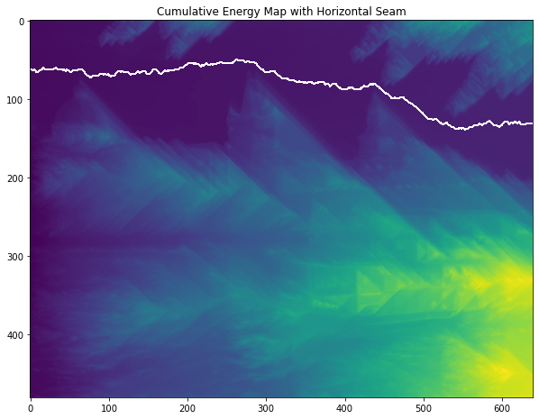

```python
energy_seam_example = dllToArray(findSeam(energy_DLL))
plt.imshow(energy_seam_example)
plt.title("Cumulative Energy Map with Horizontal Seam")
plt.show()
```

### Step 4: Remove the nodes that belong to the seam

- Call `removeSeam` function to remove –infinity (NINF) value nodes that represent that seam.

#### **[Function to implement]**

- `removeSeam` calls `removeNodeRecursive` function which recursively removes the NINF node and “stitches” the nearby nodes.
- You need to implement `removeNodeRecursive`.

For testing the code, you can use the below toy example which

1. manually constructs an energy map and image in 2D arrays
2. convert them into 2D DLLs
3. find the seams (because of how `findSeam` works, the path with 0 values turn into NINF)
4. remove the seams for both energy map and image
5. compare against the solution which we know by how we constructed the energy map and image

```python
# Manually construct a small energy map and image
toy_energy_matrix = np.array([[1, 2, 3, 4],
                [0, 6, 7, 0],
                [9, 0, 0, 12],
                [13, 14, 15, 16]])
toy_image_matrix = np.array([[10, 20, 30, 40],
                [50, 60, 70, 80],
                [90, 100, 110, 120],
                [130, 140, 150, 160]])
print('toy_energy_matrix:')
print(toy_energy_matrix)
print()
print('toy_image_matrix:')
print(toy_image_matrix)
print()

# Convert them into 2D DLLs and display. Should be identical to above.
toy_energy_DLL = constructDoublyLinkedListLoop(toy_energy_matrix)
toy_image_DLL = constructDoublyLinkedListLoop(toy_image_matrix)

print('toy_energy_DLL:')
display(toy_energy_DLL)
print()
print('toy_image_DLL:')
display(toy_image_DLL)
print()

# Find the seam and display. It should replace 0's with NINFs
toy_energy_DLL = findSeam(toy_energy_DLL)
print('toy_energy_DLL with NINF seam:')
display(toy_energy_DLL)
print()

# Remove the seam and display both the reduced energy map and image
toy_image_DLL, toy_energy_DLL = removeSeam(toy_image_DLL, toy_energy_DLL)

print('toy_energy_DLL after seam removal:')
display(toy_energy_DLL)
print()
print('toy_image_DLL after seam removal:')
display(toy_image_DLL)
print()

# Since we know the correct solution, construct their 2D DLL and compare.
correct_energy_matrix = np.array([[1, 2, 3, 4],
                [9, 6, 7, 12],
                [13, 14, 15, 16]])
correct_image_matrix = np.array([[10, 20, 30, 40],
                [90, 60, 70, 120],
                [130, 140, 150, 160]])

print('reduced toy_energy_DLL vs. correct_energy_DLL:')
compareDLL(constructDoublyLinkedListLoop(correct_energy_matrix), toy_energy_DLL)
print()
print('reduced toy_image_DLL vs. correct_image_DLL:')
compareDLL(constructDoublyLinkedListLoop(correct_image_matrix), toy_image_DLL)
```

```
toy_energy_matrix:
[[ 1  2  3  4]
 [ 0  6  7  0]
 [ 9  0  0 12]
 [13 14 15 16]]

toy_image_matrix:
[[ 10  20  30  40]
 [ 50  60  70  80]
 [ 90 100 110 120]
 [130 140 150 160]]

toy_energy_DLL:
1 2 3 4
0 6 7 0
9 0 0 12
13 14 15 16

toy_image_DLL:
10 20 30 40
50 60 70 80
90 100 110 120
130 140 150 160

toy_energy_DLL with NINF seam:
1 2 3 4
-inf 6 7 -inf
9 -inf -inf 12
13 14 15 16

toy_energy_DLL after seam removal:
1 2 3 4
9 6 7 12
13 14 15 16

toy_image_DLL after seam removal:
10 20 30 40
90 60 70 120
130 140 150 160

reduced toy_energy_DLL vs. correct_energy_DLL:
DLL Comparison: Two DLLs Match!

reduced toy_image_DLL vs. correct_image_DLL:
DLL Comparison: Two DLLs Match!
```

- If you passed the above simple example, continue with Step 4 on our real energy map and image.
- Since each call to `findSeam` and `removeSeam` only reduces the image by 1 pixel, we set `reduce_size` to repeat this seam removal process multiple times. Currently, `reduce_size = 40` so the image height will reduce by exactly 40 pixels.

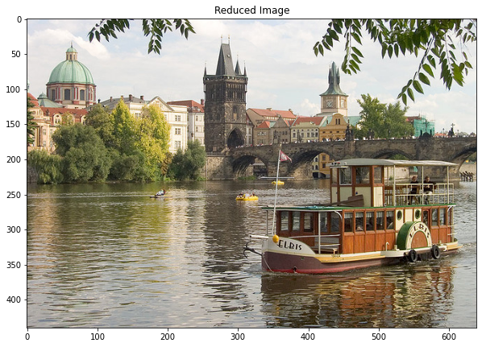

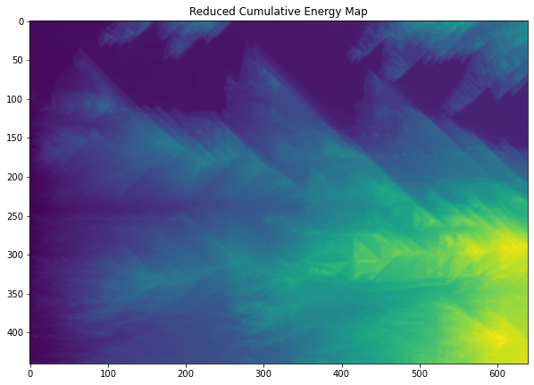

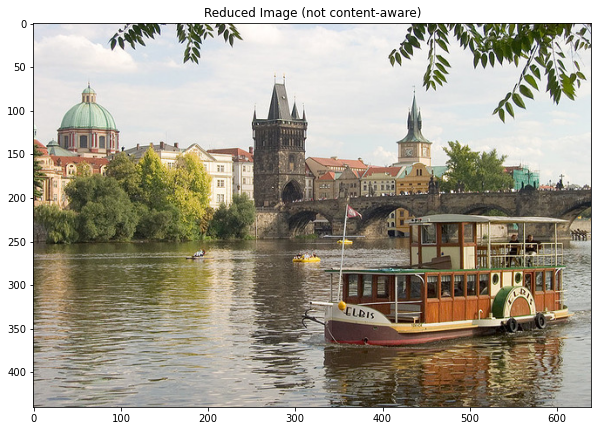

```python
reduce_size = 40
for i in range(reduce_size):
    energy_DLL = findSeam(energy_DLL)
    image_DLL, energy_DLL = removeSeam(image_DLL, energy_DLL)

reduced_image = dllToArray(image_DLL)
plt.imshow(reduced_image)
plt.title("Reduced Image")
plt.show()

reduced_energy_map = dllToArray(energy_DLL)
plt.imshow(reduced_energy_map)
plt.title("Reduced Cumulative Energy Map")
plt.show()

reduced_image_naive = contentUnawareResize(image_matrix, reduce_size)
plt.imshow(reduced_image_naive)
plt.title("Reduced Image (not content-aware)")
plt.show()
```

### End of Part 2

- When you turn in your HW, make sure you run the entire `assignment2.ipynb` so it contains all the outputs you want to show.